# Using APIs

## Requirements

**Required File**

**[NClibraries.csv](http://guides.lib.unc.edu/ld.php?content_id=41391908)**  
Save this file to your working directory.

**Packages**

Install and load the necessary packages as shown below.

```r
install.packages("httr", repos = "http://cran.us.r-project.org")
install.packages("stringr", repos = "http://cran.us.r-project.org")
install.packages("jsonlite", repos = "http://cran.us.r-project.org")

library(httr)
library(stringr)
library(jsonlite)
```

## What is an API?

API stands for **Application Programming Interface**. Web APIs allow different web apps and programming languages to communicate and work together. For example, Twitter provides an API for programmers who want to make an app that works with Twitter. The Twitter API allows them to retrieve data from Twitter, search Twitter, post to Twitter, etc. using a programming langauge like Python, Javascript or R.

## Limitations of APIs

A limitation of working with APIs is that every API is different and uses different **HTTP methods** and **parameters** (ways of communicating with web servers). There is no single chunk of code in R that will work with every API.

APIs also come with **legal limitations** on what you can do with the data you retrieve from them. Many API publishers state in their **Terms and Conditions** that the data can only be used for a very specific purpose. We will be using an **open API** for this lesson. Open APIs are often free and provide data without copyright. However, a publisher may still limit how the API can be legally used, which is why it is important to always read the Terms and Conditions before using any API for research that will be published or shared. Often, the best course of action is to contact the API publisher and make sure you have permission to use their data.

## API Keys

In order to use an API, most publishers will require you to sign up and obtain a **key**. The key is like a password you must submit whenever you use the API. It allows publishers to make sure no one is abusing their service by requesting too much information from their servers.

To complete this lesson, you will need a Mapquest API key. Below are the steps for obtaining one:

1. Go to developer.mapquest.com
2. Click on **Get your Free API Key**
3. Fill out the form and click **Sign Me Up**
4. Click **Create a New Key**
5. Type whatever you want into **App Name**. Leave **Callback URL** blank
6. Click **Create Key**

## Our Dataset

Let’s take a look at the dataset we’re working with. Read your CSV file into a data frame.

```r
nclibraries <- read.csv("NClibraries.csv")
```

View the data frame in RStudio by clicking on the **nclibraries** object in your **Environment**.

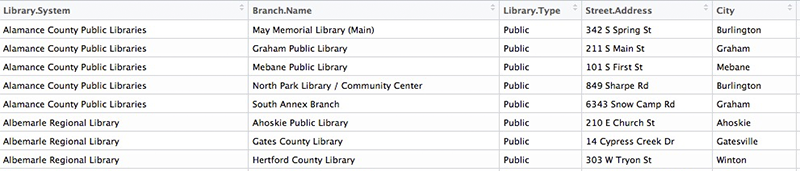

You can see that it includes a multitude of information about libraries in North Carolina. Notice that we have street addresses for these libraries. What if we wanted to plot them on a map? Most GIS tools cannot map locations by street address. Instead, they require latitudes and longitudes. The method of converting a street address into geographic coordinates is called **geocoding**. In this lesson, we will geocode our street addresses to obtain latitude and longitude information.

## Our API

The API we will use to geocode our locations is the Mapquest Open Geocoding API. As mentioned above, every API is different, so you will need to read an API’s documentation in order to know how to use it. Take a look at the [documentation for our API](https://developer.mapquest.com/documentation/open/geocoding-api/).

You’ll notice that this API uses two common HTTP methods: **GET** and **POST**. GET allows us to read information from the server, and POST allows us to create information on the server. Since we are not developing any type of software that would, for example, post a tweet on someone’s Twitter account, we’ll be using only the GET method in this lesson.

Each time we use a GET, POST or other HTTP method, we are making a **request** to the API. Scroll down to the bottom of the API’s documentation page and look at the **5-box address request** example. This example shows us how to format the type of request we want to make for this lesson. Let’s take a look at the anatomy of this request.

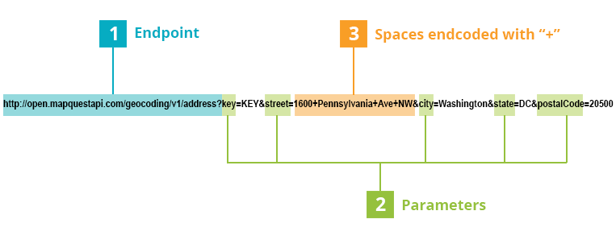

1. This is the **endpoint** for our API - a location where we can communicate with it. Like many endpoints, it ends in a question mark.
2. These are **parameters**. Parameters allow us to provide information to the API and set different options. Note that the first parameter is our key.
3. HTTP does not allow spaces, so the API requires a street address that uses **plus signs** instead of spaces. This is something we will need to change in our data.

Now, copy and paste the 5-box address request into the address bar of your web browser and press enter. The information that displays on the screen is the response to our request.

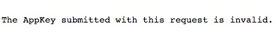

We have a problem! We didn’t include our key, so the request didn’t work.

Go to developer.mapquest.com and click on **Hi (your username)** in the top right. Under My Keys, copy the string of characters associated with your application.

[figure not shown]

Now, try your request again, this time replacing the word KEY with the key you just copied.

## JSON Format

Take a look at the data that the API returned. Can you see the latitude and longitude? They’re in there, I promise!

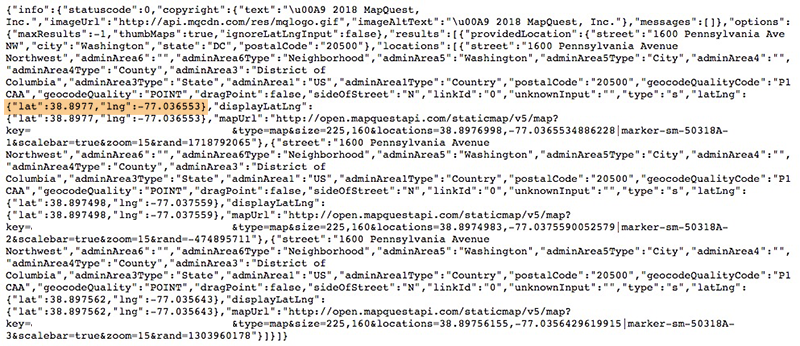

We aren’t used to working with this type of data. We usually work with datasets that have rows and columns, otherwise known as **tabular data**. Most web applications use a different format known as **JSON**, or JavaScript Object Notation. If we want to use the API’s response in our data frame, we will need to write some code that can process JSON formatted data.

## Getting Started

Now that we know what we’re working with, let’s get started. First, we need to remember our endpoint and key. Let’s keep track of them by creating two objects in R.

```r
endpoint <- "http://open.mapquestapi.com/geocoding/v1/address?"
key <- "" #paste your key inside these quotes
```

Before we start making requests, we need to make some changes to our data frame. First off, we need to supply a state as part of the address for each location. Since all of our locations are in North Carolina, we don’t have a column for state in our data frame. Let’s fix that now.

```r
#create a state column and fill all cells with 'NC'
nclibraries$state <- "NC"
```

To geocode our addresses, we will need to make a seperate API request for each location. That means we need to build URLs for our requests similar to the one we saw in our example. We can add those to a new column in the data frame too. We’ll do that by using the `paste()` function we learned about in our last lesson on strings.

```r
#create an API URL column and construct API request for each address
nclibraries$APIurl <- paste(endpoint,                                   #start with the endpoint
                            "key=", key,                                #add in our key
                            "&street=", nclibraries$Street.Address,   #remaining parameters...
                            "&city=", nclibraries$City,
                            "&state=", nclibraries$State,
                            "&postalCode=", nclibraries$ZIP.Code,
                            sep="")                                     #remove seperator
```

Remember the issue with our street address? Spaces are a problem in HTTP. We need to replace them with plus signs, which we can also do using one of the stringr functions we learned in the last lesson.

```r
nclibraries$APIurl <- str_replace_all(nclibraries$APIurl, " ", "+")
```

Now we should have a full API request for each seperate location as part of our data frame. There’s one more thing we need to do before we make requests, though. We need to add columns for the latitude and longitude information to go into.

```r
#Create empty latitude and longitude columns
nclibraries$lat <- ""
nclibraries$long <- ""
```

## Making the First Request

Let’s pick the third row in our data frame to test out our first request. We’ll be using the `GET()` function from the **httpr** package and saving the results in an object called **response**.

```r
response <- GET(url = nclibraries$APIurl[3])
```

Take a look at our **response** object.

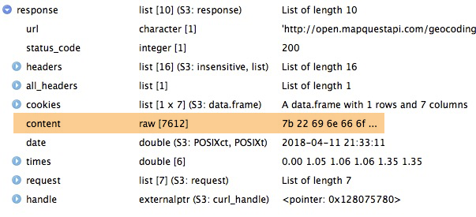

It’s a list with a bunch of things in it, none of which are entirely useful to us right now. The item called “content” is what’s currently holding our JSON data, but it’s encoded in raw bytes! We will use the `content()` function in the httr package and `fromJSON()` function in the jsonlite package to turn it into a format we can use.

```r
json <- fromJSON(content(response, "text"), flatten = TRUE)
```

Now look at our **json** object.

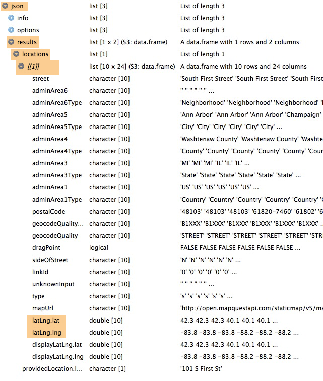

It includes a data frame `[[1]]` that is embedded within several lists. The indexing for the latitude and longitude information is `json$results$locations[[1]]$latLng.lat` and `json$results$locations[[1]]$latLng.lng`. We can add the coordinates to our dataset columns like so:

```r
nclibraries$lat[3] <- json$results$locations[[1]]$latLng.lat   #Put latitude in lat column
nclibraries$long[3] <- json$results$locations[[1]]$latLng.lng  #Put longitude in long column
```

## Looping

The loop below uses all the same code we created above, but wraps it inside of a function called `for()`. `for()` allows us to **iterate** through every record in our data frame. When using the `for()` loop, we replace the row index (3) with a placeholder. The name of the placeholder is arbitrary, but I used the letter i for “iteration”. Below, we are telling the `for()` loop to start at row 1 and stop at row 532.

Note that I have also added a line of code to print the row that the loop is currently processing. This is to track our progress because the loop will take a while to complete. **Loops in R can perform rather slowly. If at any time you want to stop the loop, you can press the stop sign that appears in the upper right of your console.**

```r
for (i in 1:532) {
  response <- GET(url = nclibraries$APIurl[i])                   #Make API request
  json <- fromJSON(content(response, "text"), flatten = TRUE)    #Save response in JSON format
  nclibraries$lat[i] <- json$results$locations[[1]]$latLng.lat   #Put latitude in lat column
  nclibraries$long[i] <- json$results$locations[[1]]$latLng.lng  #Put longitude in long column
  print(i)                                                       #Track progress
}
```

Once the loop finishes, your data frame should contain all the coordinates you need to build a map!

## Exercises

1. The Gaurdian provides an Open API with access to all of their news content. [Register for a key](http://open-platform.theguardian.com/).
2. Read the [documentation](http://open-platform.theguardian.com/documentation/) on how to use the API to make a **content** request.
3. Construct and run an API request that asks for articles on a subject you’re interested in (either through keyword or tag). You should receive the information for at least **10 articles** in return.
4. Create a data frame with the information from those articles. The data frame should have the following columns:
- Publication Date
- Title
- Byline
- URL

## [Let us know what you think of this lesson!](https://unc.az1.qualtrics.com/jfe/form/SV_8e1zRY2rlFUYBMx)